# Classification of Weight Lifting Performing Quality

```r
library(MASS)
library(rpart)
```

In this report it will be shown the process of building a simple machine learning algorithm to classify data from the ‘Weight Lifting Exercise Dataset’. This dataset contains data from accelerometers on the belt, forearm, arm, and dumbell of 6 participants, which performed some weight lifting exercises with varying degrees of quality. Our algorithm will learn from a dataset of around 19000 observations, and will then attempt to classify 20 new transactions into their corresponding quality level.

Our first step is loading the data. For this case, the first 7 columns are removed, this is because these are timestamps and user identifiers, which are evidently not useful for the classification of whether the exercise was performed correctly or not. The variables are also converted to numeric values, and NA values replaced with zeros.

```r
pmlTrain <- read.csv("pml-training.csv")
pmlTrain <- pmlTrain[,-c(1:7)]
pmlTrain[,-153] <- sapply(pmlTrain[,-153],as.numeric)

pmlTest <- read.csv("pml-testing.csv")
pmlTest <- pmlTest[,-c(1:7)]
pmlTest[,-153] <- sapply(pmlTest[,-153],as.numeric)
```

```r
fit <- glm(as.numeric(classe) ~ .,data=pmlTrain,na.action=na.omit)
step <- stepAIC(fit,direction="both")
step$formula
pmlTrain[is.na(pmlTrain)] <- 0
pmlTest[is.na(pmlTest)] <- 0
```

[output not shown]

After trying with several type of models, we will be using a recursive partitioning tree as our learning model. The formula entered is the one obtained with backwards elimination. We tested with a generalized linear model, and a neural network, but the highest accuracy on the crossvalidation on training set was obtained with a CART model (classification and regression tree).

```r
modelRP <- rpart(classe ~ roll_belt + pitch_belt + yaw_belt + kurtosis_picth_belt + max_roll_belt + min_pitch_belt + var_total_accel_belt + stddev_roll_belt +  var_roll_belt + avg_pitch_belt + var_pitch_belt + stddev_yaw_belt + var_yaw_belt + gyros_belt_x + accel_belt_x + accel_belt_y + accel_belt_z + magnet_belt_y + magnet_belt_z + roll_arm + pitch_arm + yaw_arm + stddev_roll_arm + var_roll_arm + avg_pitch_arm + stddev_yaw_arm + var_yaw_arm + gyros_arm_x + gyros_arm_y + accel_arm_z + magnet_arm_x + magnet_arm_y + magnet_arm_z + kurtosis_picth_arm + max_picth_arm + min_roll_arm + min_pitch_arm + amplitude_roll_arm + roll_dumbbell + yaw_dumbbell + max_picth_dumbbell + min_pitch_dumbbell + amplitude_pitch_dumbbell + amplitude_yaw_dumbbell + total_accel_dumbbell + avg_roll_dumbbell + stddev_roll_dumbbell + stddev_pitch_dumbbell + var_pitch_dumbbell + stddev_yaw_dumbbell + var_yaw_dumbbell + gyros_dumbbell_x + gyros_dumbbell_y + gyros_dumbbell_z + accel_dumbbell_x + accel_dumbbell_y + accel_dumbbell_z + magnet_dumbbell_x + magnet_dumbbell_z + kurtosis_picth_forearm + skewness_pitch_forearm + max_yaw_forearm + min_pitch_forearm + total_accel_forearm + avg_roll_forearm + stddev_roll_forearm + var_roll_forearm + avg_pitch_forearm + stddev_pitch_forearm + var_pitch_forearm + avg_yaw_forearm + stddev_yaw_forearm + var_yaw_forearm + gyros_forearm_x + accel_forearm_y + accel_forearm_z + magnet_forearm_y + magnet_forearm_z,data=pmlTrain,method="class",control=rpart.control(cp=0.001))
```

We can review our model by plotting two things: 1) The change in the relative error and the Complexity Parameter (CP) as the three grows. The complexity parameter is the factor by which the splitting of a node reduces the relative error. (i.e. reducing relative error from .35 to .2 gives a CP of .15) 2) The table of CP values where we can see the cross validation error and the CP value attained in every level of the tree.

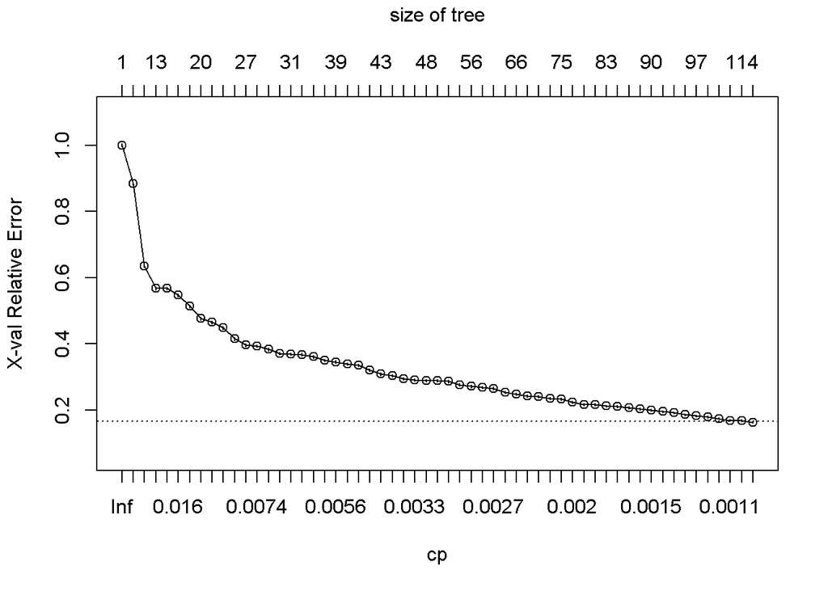

```r
plotcp(modelRP)
```

```r
printcp(modelRP)
```

```
##
## Classification tree:
## rpart(formula = classe ~ roll_belt + pitch_belt + yaw_belt +
##     kurtosis_picth_belt + max_roll_belt + min_pitch_belt + var_total_accel_belt +
##     stddev_roll_belt + var_roll_belt + avg_pitch_belt + var_pitch_belt +
##     stddev_yaw_belt + var_yaw_belt + gyros_belt_x + accel_belt_x +
##     accel_belt_y + accel_belt_z + magnet_belt_y + magnet_belt_z +
##     roll_arm + pitch_arm + yaw_arm + stddev_roll_arm + var_roll_arm +
##     avg_pitch_arm + stddev_yaw_arm + var_yaw_arm + gyros_arm_x +
##     gyros_arm_y + accel_arm_z + magnet_arm_x + magnet_arm_y +
##     magnet_arm_z + kurtosis_picth_arm + max_picth_arm + min_roll_arm +
##     min_pitch_arm + amplitude_roll_arm + roll_dumbbell + yaw_dumbbell +
##     max_picth_dumbbell + min_pitch_dumbbell + amplitude_pitch_dumbbell +
##     amplitude_yaw_dumbbell + total_accel_dumbbell + avg_roll_dumbbell +
##     stddev_roll_dumbbell + stddev_pitch_dumbbell + var_pitch_dumbbell +
##     stddev_yaw_dumbbell + var_yaw_dumbbell + gyros_dumbbell_x +
##     gyros_dumbbell_y + gyros_dumbbell_z + accel_dumbbell_x +
##     accel_dumbbell_y + accel_dumbbell_z + magnet_dumbbell_x +
##     magnet_dumbbell_z + kurtosis_picth_forearm + skewness_pitch_forearm +
##     max_yaw_forearm + min_pitch_forearm + total_accel_forearm +
##     avg_roll_forearm + stddev_roll_forearm + var_roll_forearm +
##     avg_pitch_forearm + stddev_pitch_forearm + var_pitch_forearm +
##     avg_yaw_forearm + stddev_yaw_forearm + var_yaw_forearm +
##     gyros_forearm_x + accel_forearm_y + accel_forearm_z + magnet_forearm_y +
##     magnet_forearm_z, data = pmlTrain, method = "class", control = rpart.control(cp = 0.001))
##
## Variables actually used in tree construction:
##  [1] accel_arm_z         accel_belt_x        accel_belt_z
##  [4] accel_dumbbell_x    accel_dumbbell_y    accel_dumbbell_z
##  [7] accel_forearm_z     gyros_arm_x         gyros_arm_y
## [10] gyros_belt_x        gyros_dumbbell_x    gyros_dumbbell_y
## [13] gyros_dumbbell_z    magnet_arm_x        magnet_arm_y
## [16] magnet_arm_z        magnet_belt_y       magnet_belt_z
## [19] magnet_dumbbell_x   magnet_dumbbell_z   magnet_forearm_y
## [22] magnet_forearm_z    pitch_arm           pitch_belt
## [25] roll_arm            roll_belt           roll_dumbbell
## [28] total_accel_forearm yaw_arm             yaw_belt
## [31] yaw_dumbbell
##
## Root node error: 14042/19622 = 0.72
```

[output cut: 46 more lines]

```
## 43 0.0019     81      0.19   0.22 0.0036
## 44 0.0018     82      0.18   0.21 0.0036
## 45 0.0017     83      0.18   0.21 0.0036
## 46 0.0016     85      0.18   0.21 0.0035
## 47 0.0016     87      0.17   0.20 0.0035
## 48 0.0015     89      0.17   0.20 0.0035
## 49 0.0014     90      0.17   0.20 0.0035
## 50 0.0014     92      0.17   0.19 0.0034
## 51 0.0013     95      0.16   0.19 0.0034
## 52 0.0012     96      0.16   0.18 0.0034
## 53 0.0012    103      0.15   0.18 0.0033
## 54 0.0011    105      0.15   0.17 0.0033
## 55 0.0011    112      0.14   0.17 0.0033
## 56 0.0010    113      0.14   0.17 0.0032
## 57 0.0010    115      0.14   0.16 0.0032
```

From these values we select an appropiate CP level, and will prune the tree at that cP. All nodes with CP value smaller than the one selected will be removed from the tree. Finding a good balance in this value is important to avoid overfitting. After pruning we plot the tree to have a visual idea of how it looks.

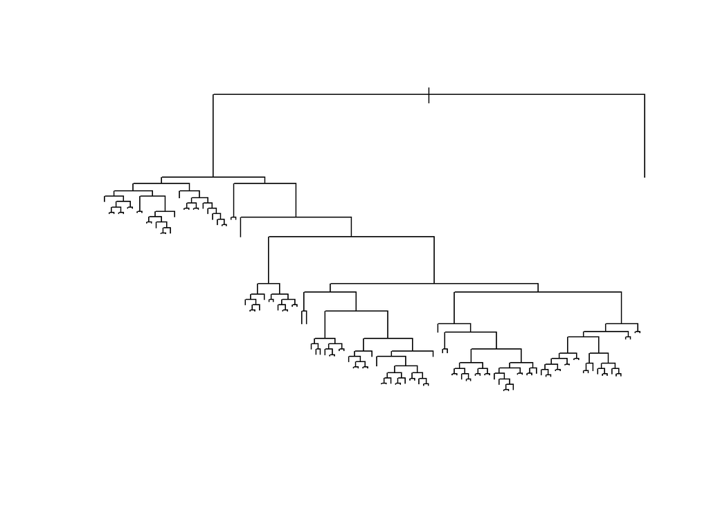

```r
minCP <- modelRP$cptable[which.min(modelRP$cptable[,"xerror"]),"CP"]
modelRP <- prune(modelRP,cp=minCP)
plot(modelRP)
```

Once the tree is pruned we can predict values for our existing test data. The result is a matrix with one column per class and one row per observation in the new data. Each column in a row will indicate the probability of that row belonging to the class in its column.

```r
predRP <- predict(modelRP,newdata=pmlTest[,labels(modelRP$terms)],type=c("prob"))
predRP
```

```
##           A       B        C        D       E
## 1  0.000000 0.90000 0.000000 0.000000 0.10000
## 2  0.960323 0.01210 0.009415 0.007397 0.01076
## 3  0.363636 0.63636 0.000000 0.000000 0.00000
## 4  0.988166 0.01183 0.000000 0.000000 0.00000
## 5  0.962963 0.03704 0.000000 0.000000 0.00000
## 6  0.000000 0.94286 0.000000 0.000000 0.05714
## 7  0.000000 0.00000 0.093960 0.893960 0.01208
## 8  0.095238 0.05357 0.000000 0.797619 0.05357
## 9  0.902439 0.04656 0.028825 0.022173 0.00000
## 10 0.960323 0.01210 0.009415 0.007397 0.01076
## 11 0.000000 0.13889 0.055556 0.027778 0.77778
## 12 0.005597 0.06343 0.819030 0.085821 0.02612
## 13 0.041353 0.88722 0.011278 0.011278 0.04887
## 14 0.960323 0.01210 0.009415 0.007397 0.01076
## 15 0.000000 0.02339 0.000000 0.005848 0.97076
## 16 0.000000 0.12069 0.000000 0.000000 0.87931
## 17 0.883721 0.07558 0.000000 0.040698 0.00000
## 18 0.873188 0.01449 0.000000 0.101449 0.01087
## 19 0.810000 0.15000 0.020000 0.000000 0.02000
## 20 0.009967 0.90365 0.023256 0.019934 0.04319
```